# Likelihood intro/reminder

Ben Bolker (some material from Steve Ellner)

14 May 2019

Licensed under the [Creative Commons attribution-noncommercial license](http://creativecommons.org/licenses/by-nc/3.0/). Please share & remix noncommercially, mentioning its origin.

# Likelihood

## Definition

- probability of data given a model (structure & parameters)
- in R: distributions via `d*` functions (base, [Distributions Task View](https://cran.r-project.org/web/views/Distributions.html))
- usually: complex model for the *location*, simpler models for the *scale* and *shape*
  - e.g. Gamma with fixed shape, varying mean

## MLEs are consistent and asymptotically Normal

- *consistent* = converge to the true values as the number of independent observations grows to infinity
- asymptotic Normality is the basis for the approximate (Wald) standard errors from `summary()`

## MLEs are asymptotically efficient

- important but a bit delicate.
- as number of independent observations $n$ increases, the standard errors on each parameter decrease in proportion to $C/\sqrt{n}$ for some constant $C$
- **Asymptotically efficient** means that there is no unbiased way of estimating parameters for which the standard errors shrink at a strictly faster rate (e.g., a smaller value of $C$, or a higher power of $n$ in the denominator).

## MLEs = Swiss Army knife

- MLEs make sense
- lots of justifying theory
- when it can do the job, it’s rarely the best tool for the job but it’s rarely much worse than the best (at least for large samples)
- most statistical models (least-squares, GLMs) are special cases of MLE

## Inference

- **Wald approximation**: quadratic approximation (parabolas/ellipses)
  - p-values: $Z$-scores ($\hat \beta/\sigma_{\hat \beta}$ N(0,1)$)
  - confidence intervals: based on $N(\hat \beta, \sigma_{\hat \beta})$
  - strongly asymptotic
- **likelihood**:
  - p-values: likelihood ratio test ($-2 \Delta \log L \sim \chi^2_n$)
  - CIs: *likelihood profiles*
- **bootstrapping**
  - nonparametric (slow, requires independence)
  - parametric (slow, model-dependent)
- **Bayesian**
  - requires priors
  - strongly model-dependent
  - often slow
  - … but solves many problems

Beyond Normal errors, finite-size corrections are tricky

## …

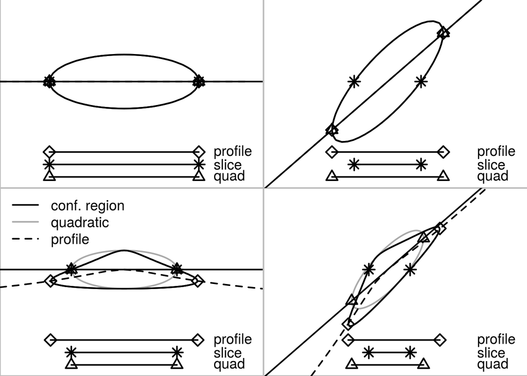